# Lab4

Soyeon Lee

9/29/2020

1. Estimate the letter occurrence probabilities of all 26 letters in English by measuring a paragraph of English text from wikipedia. (hint use strsplit() to split a paragraph into individual letters) (1 point). Confidence:0

```r
wikipedia<-"Jacob Cornelisz van Oostsanen (before 1470 – 1533) was a Northern Netherlandish painter and designer of woodcuts. This oil-on-panel painting, by his son Dirck Jacobsz., depicts Van Oostsanen painting a portrait of his wife Anna. Though Van Oostsanen had died in 1533, his wife lived until around 1550, the year in which this work was painted. Its format ingeniously incorporates the viewer in its fiction. The painter looks out, presumably at his subject, whose likeness he is depicting. The work may have been intended to serve as a memorial to Jacobsz.'s parents, to be installed above the couple's tomb in a church."

  #deconstruct the words, and convert all to lower case
  #organize them into a table to create a data frame
  #exclude everything but letters in letter_counts and save as final
  #add the probabilities column to the final, and print table
wiki_letters<-unlist(strsplit(wikipedia,split=""))
lower_case<-tolower(wiki_letters)

letter_counts<-table(lower_case)
letter_counts<-data.frame(letter_counts)

library(dplyr)
final<-letter_counts%>%
  filter(lower_case%in%letters==TRUE)

total_letters<-sum(final$Freq)

final<-final%>%
  mutate(probabilities=Freq/total_letters)

knitr::kable(final)
```

| lower_case | Freq | probabilities |
| --- | --- | --- |
| a | 40 | 0.0835073 |
| b | 11 | 0.0229645 |
| c | 15 | 0.0313152 |
| d | 16 | 0.0334029 |
| e | 50 | 0.1043841 |
| f | 7 | 0.0146138 |
| g | 6 | 0.0125261 |
| h | 24 | 0.0501044 |
| i | 45 | 0.0939457 |
| j | 4 | 0.0083507 |
| k | 5 | 0.0104384 |
| l | 14 | 0.0292276 |
| m | 6 | 0.0125261 |
| n | 45 | 0.0939457 |
| o | 40 | 0.0835073 |
| p | 13 | 0.0271399 |
| r | 24 | 0.0501044 |
| s | 39 | 0.0814196 |
| t | 39 | 0.0814196 |
| u | 10 | 0.0208768 |
| v | 8 | 0.0167015 |
| w | 10 | 0.0208768 |
| y | 5 | 0.0104384 |
| z | 3 | 0.0062630 |

2. Generate “random” strings of letters that are sampled from a distribution where letter occurrence probability is the same as natural English. Use the probabilities for each letter from this wikipedia article, or use your own estimates from the previous question (2 points). Confidence:50

```r
  #create a sequence and organize them in a matrix
  #paste by row the letters, to create 5 letter strings
my_strings<-sample(final$lower_case,50*5,replace=TRUE)

random_strings<-matrix(my_strings,ncol=5)

my_letters<-c()
for(i in 1:dim(random_strings)[1]){
  my_letters[i]<-paste(random_strings[i,],collapse = "")
}
my_letters
```

```
##  [1] "etygn" "tamyr" "myrcf" "vdiin" "gtmsp" "ufiau" "tejjy" "vloft" "smaif"
## [10] "yzwcu" "yubbv" "pkmrw" "jwnce" "aklok" "cpmps" "satta" "rlvbk" "unyou"
## [19] "klgyb" "vesbm" "esjga" "nlghy" "wkznn" "ultzh" "nnejb" "bbjfk" "drthj"
## [28] "hoduk" "doisj" "envjd" "roijf" "ubtyk" "eytri" "mevto" "owmsr" "rclke"
## [37] "vsray" "gndae" "kuuzi" "lhsil" "dtnzz" "pydeg" "hbtcn" "frbrk" "doyzy"
## [46] "gcaye" "gtpjg" "eeyfg" "uruag" "tcjbc"
```

3. Generate a random walk of 10,000 steps. In a random walk, you are simulating the process of randomly taking a step up or down, as if you are on an infinite staircase. At each step you flip a coin. If you get heads you go up one step, if you get tails you go down one step. Start on step 0, then simulate a random walk for 10,000 steps. Your vector should preserve the step number for each step. For example, if the the first three steps were all heads, then the vector would begin with 0,1,2,3, which indicates a single step up each time. Plot the first 1,000 steps. (1 point) Confidence:80

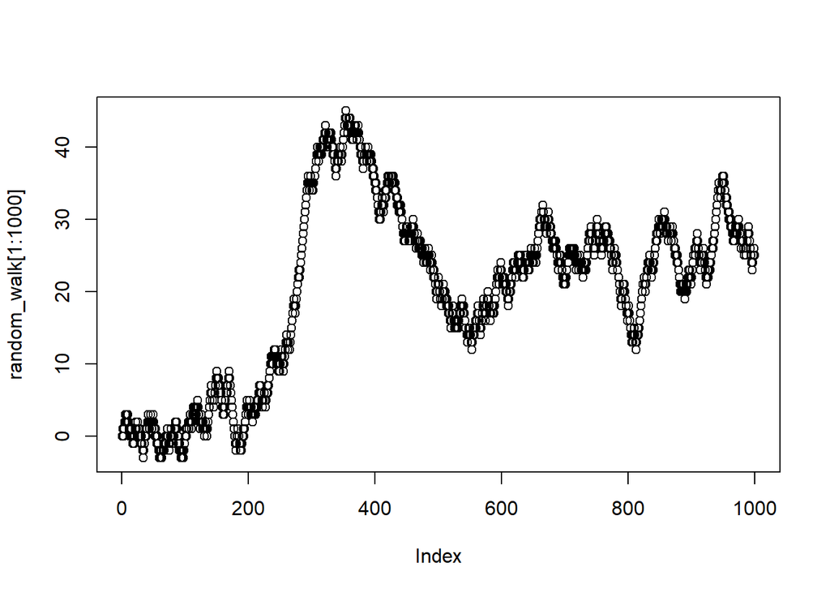

```r
  #simulate coin flips
  #initialize vectors
  #at each iteration, steps are added to the previous position of random walk
sim_flips<-sample(c(1,-1),9999,replace=TRUE)

steps<-c()
random_walk<-c(0)
for(i in 1:length(sim_flips)){
  steps[i]<-sim_flips[i]
  random_walk[i+1]<-steps[i]+random_walk[i]
}
plot(random_walk[1:1000])
```

4. What was the most positive and most negative step reached out of 10,000? (1 point) Confidence:90

```r
min(random_walk)
```

```
## [1] -3
```

```r
max(random_walk)
```

```
## [1] 130
```

5. What was the longest run of steps where all steps were positive numbers. For example, in the sequence: 1,2,3,2,1,0,-1,-2,-1,-2,-1,0,1,2,3; the answer is 5 because the first five values were all positive, and this was the longest sequence of positive values. (1 point). Confidence:0

```r
#covert real numbers into 0,1,or -1 for simplification
#create an empty sequence vector and set counter to 0
#at each iteration, if the number is 0,it returns 0; if not, the logical step values are added to counter.
logical_step<-sign(random_walk)

sequence<-c()
counter<-0
for(i in 1:length(logical_step)){
  if(logical_step[i]==0){
    sequence<-c(sequence, counter)
    counter<-0
  } else {
      counter<-counter+logical_step[i]
  }
}
max(sequence)
```

```
## [1] 43
```